# Laboratorio Modulo 7

Soluzioni

Author

Ottavia Epifania

# 1 Introduzione

Il dataset `DATIBASE.csv` è composto da 99 osservazioni relative alle seguenti variabili:

- `TEST`: misura quantitativa che esprime il punteggio dell’individuo a un test di personalità
- `ANNOcat`: variabile di classificazione 0/1 che indica se l’individuo appartiene alla classe di ingresso 2016 (codice 0) oppure 2018 (codice 1)
- `MC`: misura quantitativa che esprime il livello di compatibilità atteso dell’individuo con una specifica mansione lavorativa

# 2 Esercizi

Negli esercizi che seguono precedere le analisi statistico-inferenziali con opportuni metodi grafici.

## 2.1

Importare il dataset e assegnarlo alla variabile `dati`.

```r
dati = read.csv2("DATIBASE.csv")
head(dati)
```

```
  TEST ANNOcat   MC
1 61.1       0 31.1
2 54.4       1 55.3
3 52.1       1 50.8
4 78.1       1 55.9
5 76.0       1 55.8
6 68.3       0 40.8
```

```r
str(dati)
```

```
'data.frame':   99 obs. of  3 variables:
 $ TEST   : num  61.1 54.4 52.1 78.1 76 68.3 61.9 63.3 50.1 53.6 ...
 $ ANNOcat: int  0 1 1 1 1 0 1 0 0 1 ...
 $ MC     : num  31.1 55.3 50.8 55.9 55.8 40.8 49 28.8 36 41.7 ...
```

## 2.2

Studiare la relazione tra la variabile dipendente `MC` e la variabile indipendente `TEST`, senza considerare la classe di ingresso. Nello specifico:

### 2.2.1

Produrre un’adeguata rappresentazione grafica della relazione tra le due variabili.

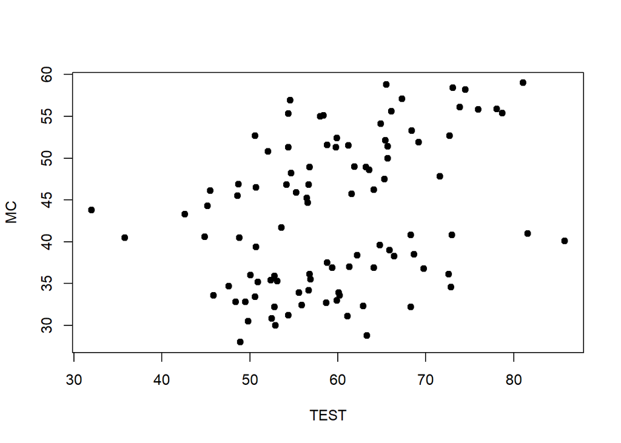

```r
plot(dati$MC ~ dati$TEST, pch = 19,
     xlab = "TEST", ylab = "MC")
```

```
Il grafico suggerisce una relazione positiva tra TEST e MC,
con una grande dispersione dei punti attorno all'andamento lineare
```

### 2.2.2

Stimare il modello di regressione lineare semplice, scrivere il sistema di ipotesi sul coefficiente angolare e commentare i risultati.

```
H0: beta1 = 0 (TEST non permette di prevedere MC)
H1: beta1 != 0 (TEST permette di prevedere MC)
```

```r
m0 = lm(MC ~ TEST, data = dati)
summary(m0)
```

```
Call:
lm(formula = MC ~ TEST, data = dati)

Residuals:
    Min      1Q  Median      3Q     Max
-15.426  -7.142   1.734   7.144  15.290

Coefficients:
            Estimate Std. Error t value Pr(>|t|)
(Intercept) 25.19290    5.11066   4.929  3.4e-06 ***
TEST         0.30068    0.08458   3.555 0.000586 ***
---
Signif. codes:  0 '***' 0.001 '**' 0.01 '*' 0.05 '.' 0.1 ' ' 1

Residual standard error: 8.287 on 97 degrees of freedom
Multiple R-squared:  0.1153,    Adjusted R-squared:  0.1062
F-statistic: 12.64 on 1 and 97 DF,  p-value: 0.0005858
```

```
Entrambi i parametri sono statisticamente significativi (alpha = .05).
Il coefficiente angolare è positivo: all'aumentare di TEST aumenta in media MC.
Il modello spiega però solo l'11% circa della variabilità di MC (R^2)
```

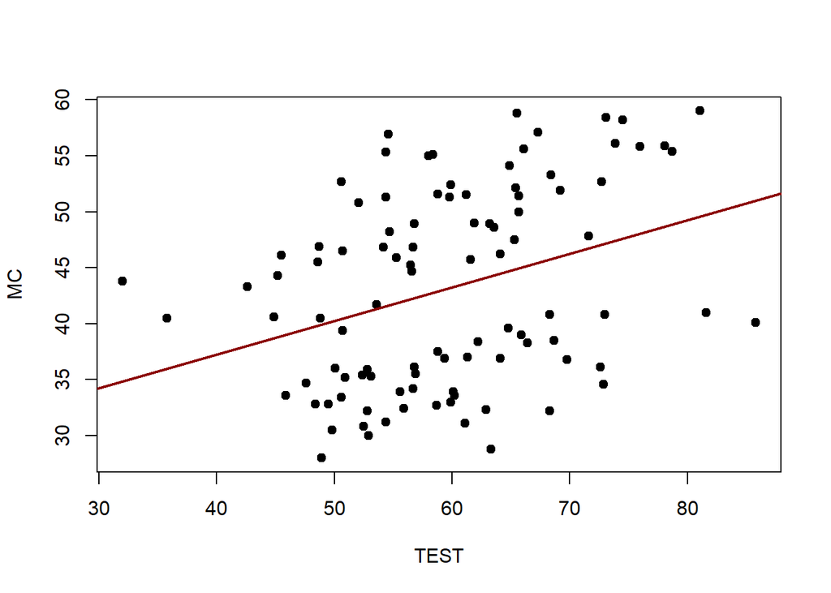

```r
plot(dati$MC ~ dati$TEST, pch = 19,
     xlab = "TEST", ylab = "MC")
abline(m0, col = "darkred", lwd = 2)
```

### 2.2.3

Calcolare gli intervalli di confidenza al 95% per i parametri del modello e confrontarli con i risultati dei test sui coefficienti.

```r
coefs = data.frame(summary(m0)$coefficients)
qt95 = qt(.975, m0$df.residual)
deltaB0 = coefs$Std..Error[1] * qt95
deltaB1 = coefs$Std..Error[2] * qt95
CIB0 = c(coefs$Estimate[1] - deltaB0, coefs$Estimate[1] + deltaB0)
CIB1 = c(coefs$Estimate[2] - deltaB1, coefs$Estimate[2] + deltaB1)
CIB0
```

```
[1] 15.04965 35.33615
```

```r
CIB1
```

```
[1] 0.1328205 0.4685393
```

```r
# confronto con la funzione confint()
confint(m0)
```

```
                 2.5 %     97.5 %
(Intercept) 15.0496519 35.3361492
TEST         0.1328205  0.4685393
```

```
Nessuno dei due intervalli contiene lo 0: coerentemente con i test,
entrambi i parametri sono significativamente diversi da 0
```

### 2.2.4

Valutare i residui del modello con almeno due rappresentazioni grafiche.

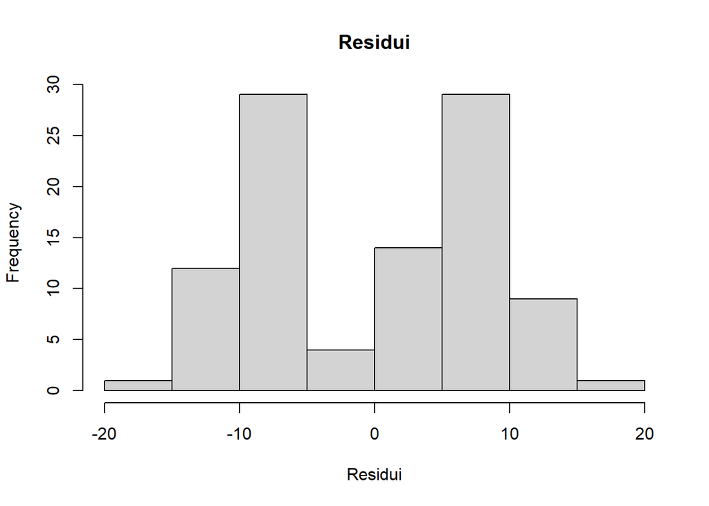

```r
hist(m0$residuals, main = "Residui", xlab = "Residui")
```

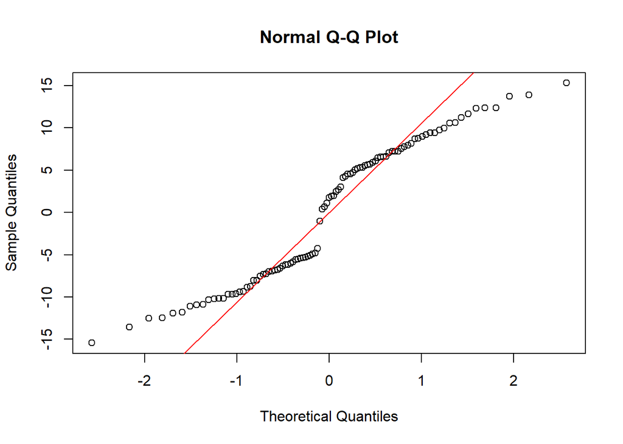

```r
qqnorm(m0$residuals)
qqline(m0$residuals, col = "red")
```

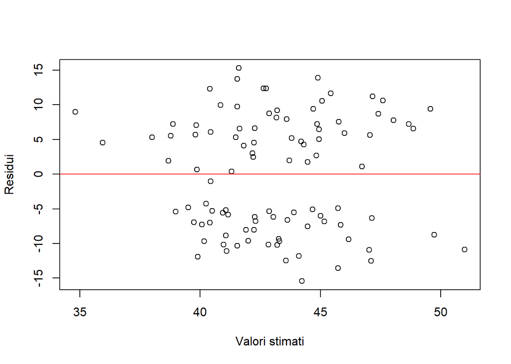

```r
plot(m0$fitted.values, m0$residuals,
     xlab = "Valori stimati", ylab = "Residui")
abline(h = 0, col = "red")
```

```
Nel grafico residui vs valori stimati si vedono due 'nuvole' di punti:
i residui sono sistematicamente positivi per un gruppo di osservazioni e negativi per l'altro.
È un segnale che manca nel modello una variabile importante (la classe di ingresso)
```

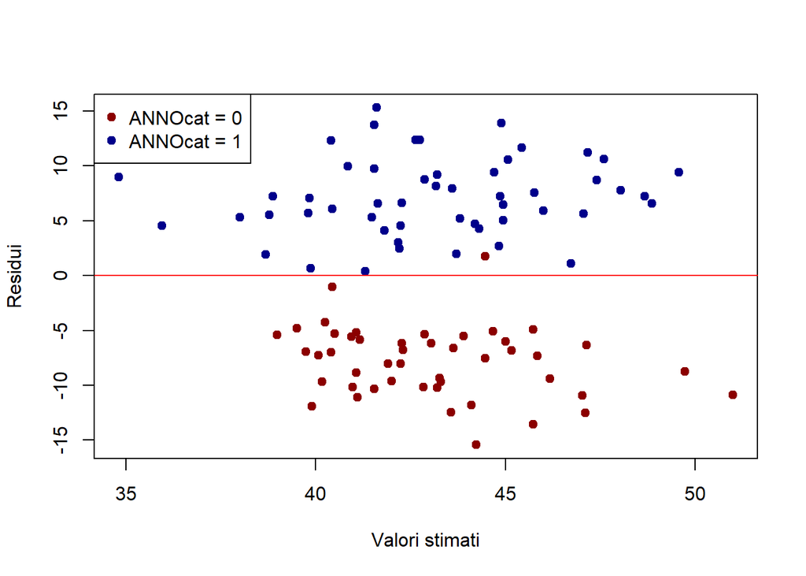

```r
plot(m0$fitted.values, m0$residuals,
     xlab = "Valori stimati", ylab = "Residui",
     pch = 19, col = ifelse(dati$ANNOcat == 0, "darkred", "darkblue"))
abline(h = 0, col = "red")
legend("topleft", pch = 19, col = c("darkred", "darkblue"),
       legend = c("ANNOcat = 0", "ANNOcat = 1"))
```

## 2.3

Studiare la relazione tra `MC` e `TEST` tenendo conto della classe di ingresso (`ANNOcat`). Nello specifico:

### 2.3.1

Produrre un’adeguata rappresentazione grafica della relazione tra le variabili in gioco.

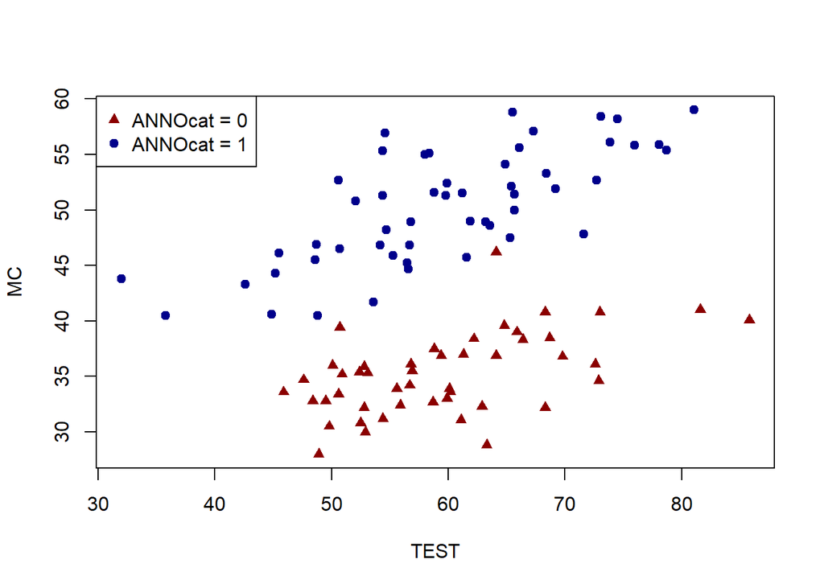

```r
plot(dati$MC ~ dati$TEST,
     pch = ifelse(dati$ANNOcat == 0, 17, 19),
     col = ifelse(dati$ANNOcat == 0, "darkred", "darkblue"),
     xlab = "TEST", ylab = "MC")
legend("topleft", pch = c(17, 19),
       col = c("darkred", "darkblue"),
       legend = c("ANNOcat = 0", "ANNOcat = 1"))
```

### 2.3.2

Identificare i diversi modelli di regressione applicabili ai dati e specificarne l’interpretazione.

```
1) Modello di regressione semplice: MC in funzione di TEST

2) Modello parallelo: MC in funzione di TEST e ANNOcat

3) Modello con interazione: MC in funzione di TEST, ANNOcat
   e interazione TEST x ANNOcat

Il primo modello non distingue tra i due gruppi (0 e 1).
Il secondo modello stima una retta per ciascun gruppo,
con intercette diverse ma lo stesso coefficiente angolare (rette parallele).
Il terzo modello stima una retta per ciascun gruppo
senza vincoli: intercette e coefficienti angolari possono essere diversi.
```

### 2.3.3

Stimare il modello parallelo e commentare i risultati.

```r
mParallel = lm(MC ~ TEST + ANNOcat, data = dati)
summary(mParallel)
```

```
Call:
lm(formula = MC ~ TEST + ANNOcat, data = dati)

Residuals:
    Min      1Q  Median      3Q     Max
-7.5295 -2.2937  0.0434  2.2970  9.6333

Coefficients:
            Estimate Std. Error t value Pr(>|t|)
(Intercept) 17.56378    2.12020   8.284 7.09e-13 ***
TEST         0.29646    0.03461   8.565 1.79e-13 ***
ANNOcat     15.00397    0.68262  21.980  < 2e-16 ***
---
Signif. codes:  0 '***' 0.001 '**' 0.01 '*' 0.05 '.' 0.1 ' ' 1

Residual standard error: 3.392 on 96 degrees of freedom
Multiple R-squared:  0.8533,    Adjusted R-squared:  0.8503
F-statistic: 279.3 on 2 and 96 DF,  p-value: < 2.2e-16
```

```
Tutti i parametri sono significativi (alpha = .05).
A parità di TEST, chi appartiene alla classe 2018 (ANNOcat = 1) ha in media
una MC più alta di chi appartiene alla classe 2016.
Il modello spiega circa l'85% della variabilità di MC, molto più del modello semplice
```

- Ricostruire le equazioni delle due rette di regressione.

```r
parallelCoef = coef(mParallel)
parallelCoef
```

```
(Intercept)        TEST     ANNOcat
 17.5637768   0.2964573  15.0039680
```

```r
# ANNOcat = 0: MC* = b0 + b1 * TEST
c(intercetta = parallelCoef[1], pendenza = parallelCoef[2])
```

```
intercetta.(Intercept)          pendenza.TEST
            17.5637768              0.2964573
```

```r
# ANNOcat = 1: MC* = (b0 + b2) + b1 * TEST
c(intercetta = parallelCoef[1] + parallelCoef[3], pendenza = parallelCoef[2])
```

```
intercetta.(Intercept)          pendenza.TEST
            32.5677447              0.2964573
```

- Rappresentare graficamente le rette di regressione.

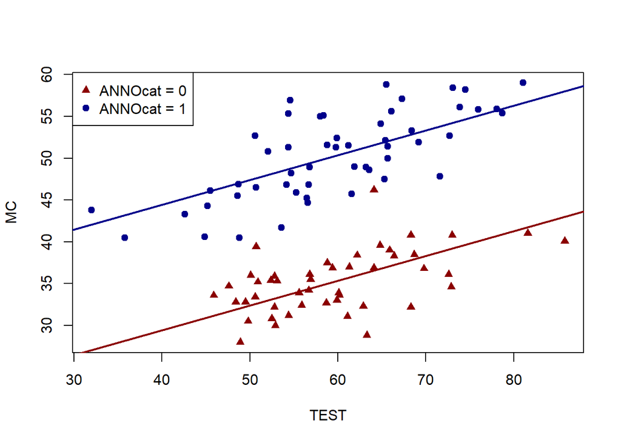

```r
plot(dati$MC ~ dati$TEST,
     pch = ifelse(dati$ANNOcat == 0, 17, 19),
     col = ifelse(dati$ANNOcat == 0, "darkred", "darkblue"),
     xlab = "TEST", ylab = "MC")
legend("topleft", pch = c(17, 19),
       col = c("darkred", "darkblue"),
       legend = c("ANNOcat = 0", "ANNOcat = 1"))
abline(parallelCoef[1], parallelCoef[2], col = "darkred", lwd = 2)
abline(parallelCoef[1] + parallelCoef[3], parallelCoef[2],
       col = "darkblue", lwd = 2)
```

- Calcolare la correlazione tra la variabile dipendente osservata e quella stimata dal modello. Che relazione c’è con l’$R^2$ del modello?

```r
cor(dati$MC, mParallel$fitted.values)
```

```
[1] 0.9237652
```

```r
cor(dati$MC, mParallel$fitted.values)^2
```

```
[1] 0.8533422
```

```r
summary(mParallel)$r.squared
```

```
[1] 0.8533422
```

```
Il quadrato della correlazione tra valori osservati e valori stimati
è uguale all'R^2 del modello
```

### 2.3.4

Ripetere l’analisi del punto precedente con il modello con interazione.

```r
mInter = lm(MC ~ TEST * ANNOcat, data = dati)
summary(mInter)
```

```
Call:
lm(formula = MC ~ TEST * ANNOcat, data = dati)

Residuals:
    Min      1Q  Median      3Q     Max
-7.2203 -2.1924 -0.1511  2.0292 10.0086

Coefficients:
             Estimate Std. Error t value Pr(>|t|)
(Intercept)  22.48978    3.31915   6.776 1.03e-09 ***
TEST          0.21375    0.05512   3.878 0.000194 ***
ANNOcat       7.00495    4.23892   1.653 0.101728
TEST:ANNOcat  0.13420    0.07022   1.911 0.058979 .
---
Signif. codes:  0 '***' 0.001 '**' 0.01 '*' 0.05 '.' 0.1 ' ' 1

Residual standard error: 3.346 on 95 degrees of freedom
Multiple R-squared:  0.8588,    Adjusted R-squared:  0.8543
F-statistic: 192.6 on 3 and 95 DF,  p-value: < 2.2e-16
```

```
Solo l'intercetta e il coefficiente di TEST sono significativi (alpha = .05).
L'interazione non è significativa: non ci sono evidenze che la relazione tra TEST e MC
sia diversa nei due gruppi. Anche il coefficiente di ANNOcat non è significativo:
in questo modello rappresenta la differenza tra i gruppi quando TEST = 0.
L'R^2 aumenta di pochissimo rispetto al modello parallelo
```

- Ricostruire le equazioni delle due rette di regressione.

```r
interCoef = coef(mInter)
interCoef
```

```
 (Intercept)         TEST      ANNOcat TEST:ANNOcat
  22.4897848    0.2137530    7.0049461    0.1342034
```

```r
# ANNOcat = 0: MC* = b0 + b1 * TEST
c(intercetta = interCoef[1], pendenza = interCoef[2])
```

```
intercetta.(Intercept)          pendenza.TEST
             22.489785               0.213753
```

```r
# ANNOcat = 1: MC* = (b0 + b2) + (b1 + b3) * TEST
c(intercetta = interCoef[1] + interCoef[3],
  pendenza = interCoef[2] + interCoef[4])
```

```
intercetta.(Intercept)          pendenza.TEST
            29.4947309              0.3479564
```

- Rappresentare graficamente le rette di regressione.

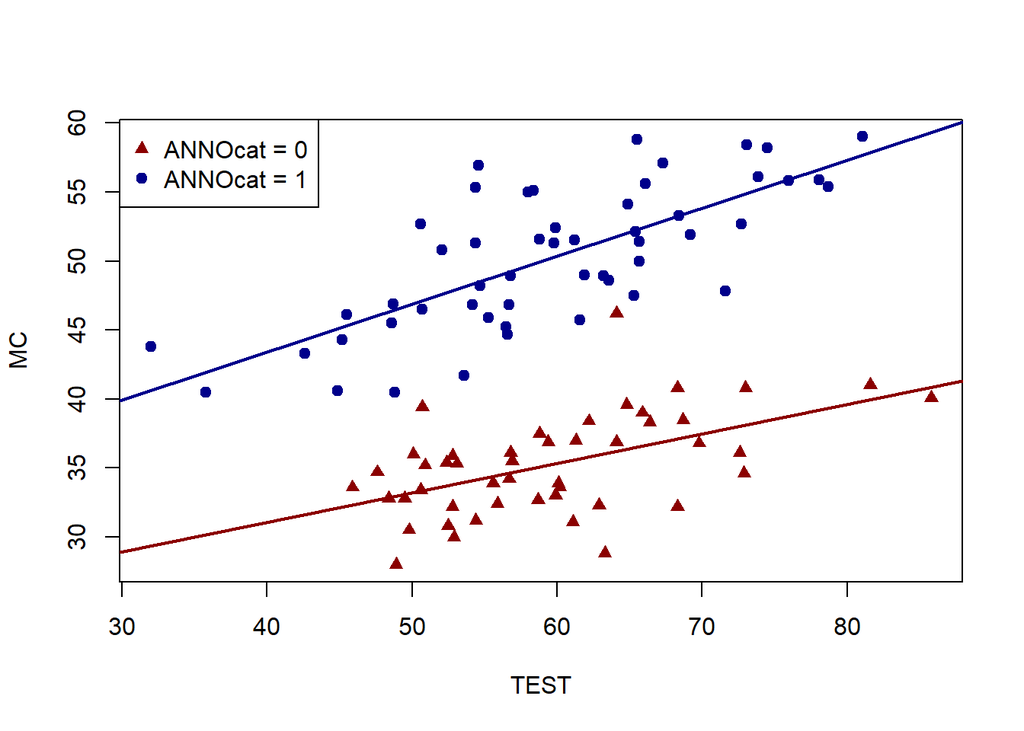

```r
plot(dati$MC ~ dati$TEST,
     pch = ifelse(dati$ANNOcat == 0, 17, 19),
     col = ifelse(dati$ANNOcat == 0, "darkred", "darkblue"),
     xlab = "TEST", ylab = "MC")
legend("topleft", pch = c(17, 19),
       col = c("darkred", "darkblue"),
       legend = c("ANNOcat = 0", "ANNOcat = 1"))
abline(interCoef[1], interCoef[2], col = "darkred", lwd = 2)
abline(interCoef[1] + interCoef[3], interCoef[2] + interCoef[4],
       col = "darkblue", lwd = 2)
```

- Calcolare la correlazione tra la variabile dipendente osservata e quella stimata dal modello.

```r
cor(dati$MC, mInter$fitted.values)
```

```
[1] 0.9267
```

### 2.3.5

Utilizzando i risultati del modello con interazione, verificare se il coefficiente angolare associato alla classe 2016 risulti significativamente diverso da 0.5 ($\alpha = .05$).

```
Per ANNOcat = 0 il coefficiente angolare è b1.
H0: beta1 = 0.5
H1: beta1 != 0.5
```

```r
coefsInter = data.frame(summary(mInter)$coefficients)
t_oss = (coefsInter$Estimate[2] - 0.5) / coefsInter$Std..Error[2]
t_oss
```

```
[1] -5.193101
```

```r
# p-value (test a due code)
2 * pt(-abs(t_oss), mInter$df.residual)
```

```
[1] 1.175449e-06
```

```r
# valore critico
qt(.975, mInter$df.residual)
```

```
[1] 1.985251
```

```
Il p-value è minore di .05 (e |t_oss| supera il valore critico):
si rifiuta H0, il coefficiente angolare della classe 2016 è diverso da 0.5
```

### 2.3.6

Calcolare gli intervalli di confidenza al 95% per i parametri del modello con interazione e commentarli.

```r
qt95 = qt(.975, mInter$df.residual)
delta = coefsInter$Std..Error * qt95
ic = data.frame(limInf = coefsInter$Estimate - delta,
                limSup = coefsInter$Estimate + delta)
rownames(ic) = rownames(coefsInter)
ic
```

```
                   limInf     limSup
(Intercept)  15.900436261 29.0791333
TEST          0.104324695  0.3231813
ANNOcat      -1.410375365 15.4202675
TEST:ANNOcat -0.005191639  0.2735985
```

```r
# confronto con la funzione confint()
confint(mInter)
```

```
                    2.5 %     97.5 %
(Intercept)  15.900436261 29.0791333
TEST          0.104324695  0.3231813
ANNOcat      -1.410375365 15.4202675
TEST:ANNOcat -0.005191639  0.2735985
```

```
Solo gli intervalli dell'intercetta e di TEST non contengono lo 0:
coerentemente con i test, sono gli unici parametri significativi
```